# Imputação de Valores Ausentes

Prof. Cesar Henrique Comin

## Valores Ausentes: como tratar

- Aprendemos a **detectar** ausências: nulos explícitos (`NaN`, `None`) e sentinelas implícitos (`-999`, `"N/A"`, `""`).
- O que colocar no lugar?
- **Imputação** = substituir cada valor ausente por uma estimativa plausível.

## Por que não simplesmente ignorar?

- A maioria dos algoritmos de aprendizado de máquina **gera um erro** ao encontrar `NaN`.
- O Pandas em geral **ignora silenciosamente** os ausentes nas agregações.

```python
import pandas as pd
import numpy as np

grades = pd.Series([7.0, np.nan, 9.0, np.nan, 5.0])
print("média:", grades.mean())          # média de 3 valores, não de 5
print("soma:", grades.sum(), "| contagem:", grades.count())
```

```
média: 7.0
soma: 21.0 | contagem: 3
```

## Mecanismo de ausência

- Antes de escolher a técnica, é preciso entender **por que** o dado está faltando.
- A literatura estatística descreve três mecanismos:
  - Missing Completely At Random (MCAR)
  - Missing At Random (MAR)
  - Missing Not At Random (MNAR)
- O mecanismo determina **quais técnicas são válidas** e quanto viés será introduzido.

## Ausência completamente aleatória (MCAR)

- A probabilidade de um valor faltar **não depende de nada**: nem do valor em si, nem das outras variáveis.
- Exemplo: um sensor que perde leituras por ruído elétrico; um formulário perdido no correio.
- Consequências:
  - Os dados observados são uma **amostra aleatória** dos dados completos.
  - Deletar as linhas é **seguro** (não enviesa), apenas reduz o tamanho da amostra.

## Ausência aleatória condicional (MAR)

- A probabilidade de faltar depende de **outras colunas observadas**, mas não do valor ausente.
- Exemplo: pacientes idosos deixam de responder o campo “renda” com mais frequência. A ausência depende de `idade`, que **está** no dataset.
- Consequências:
  - Deletar linhas **enviesa** o resultado (a base perde os idosos).
  - Como a informação está nas outras colunas, é possível **prever** o valor ausente.

## Ausência não aleatória (MNAR)

- A probabilidade de faltar depende do **próprio valor não observado**.
- Exemplos: pessoas de renda alta não declaram a renda. Pacientes que pioraram abandonam o estudo.
- Consequências:
  - A informação necessária para corrigir o viés **pode não estar** no dataset.
  - Se isso acontecer, **Nenhuma** técnica resolve o problema.
- O que fazer: registrar a ausência como informação (coluna indicadora), documentar a limitação e, se possível, coletar dados auxiliares.

## Deleção ou imputação?

- `df.dropna()` é aceitável quando: o mecanismo é MCAR **e** poucas linhas são afetadas.
- O problema é que a ausência costuma estar **espalhada** entre muitas colunas:

```python
p = 0.05          # 5% de ausência por célula, independente
n_columns = 20
print(f"Linhas completas: {(1 - p)**n_columns:.1%}")
```

```
Linhas completas: 35.8%
```

- Com apenas 5% de células ausentes, sobram ~36% das linhas: perdemos quase **2/3** da base.
- Deletar a **coluna** é razoável quando ela tem ausência massiva (ex.: > 60%) e baixa importância.

## Imputar apaga uma informação

- O fato de o valor **estar faltando** muitas vezes é informativo (especialmente sob MNAR).
- Solução barata: criar uma coluna indicadora antes de imputar.

```python
df = pd.DataFrame({"renda": [3500.0, np.nan, 8200.0, np.nan]})
df["renda_faltante"] = df["renda"].isna()
df["renda"] = df["renda"].fillna(df["renda"].median())
print(df)
```

```
    renda  renda_faltante
0  3500.0           False
1  5850.0            True
2  8200.0           False
3  5850.0            True
```

## Imputar apaga uma informação

- Com a coluna indicadora, o modelo pode então aprender que “não declarou a renda” tem significado próprio.
- Veremos que o `scikit-learn` automatiza isso com o parâmetro `add_indicator`.

## Visão geral das técnicas de imputação

| Técnica | Função/classe | Usa o quê? |
| --- | --- | --- |
| Valor fixo | `fillna` | Um valor escolhido |
| Propagação | `ffill`, `bfill` | Um valor vizinho |
| Interpolação | `interpolate` | A forma da curva |
| Estatística (sklearn) | `SimpleImputer` | Uma estatística da coluna |
| Multivariada (sklearn) | `KNNImputer`, `IterativeImputer` | As outras colunas |

# Pandas: preenchimento com valor fixo

## A função fillna

- Substitui todos os valores ausentes por um valor informado

```python
grades = pd.Series([7.0, np.nan, 9.0, np.nan, 5.0],
                   index=["Ana", "Bruno", "Carla", "Diego", "Elisa"])

print(pd.DataFrame({
    "original": grades,
    "fillna(0)": grades.fillna(0),
    "fillna(média)": grades.fillna(grades.mean()),
}))
```

```
       original  fillna(0)  fillna(média)
Ana         7.0        7.0            7.0
Bruno       NaN        0.0            7.0
Carla       9.0        9.0            9.0
Diego       NaN        0.0            7.0
Elisa       5.0        5.0            5.0
```

## `fillna` por grupo

- Preencher com a média **global** ignora a estrutura dos dados. Quase sempre existe um grupo mais informativo.

```python
df_rents = pd.DataFrame({
    "cidade": ["SP", "SP", "RJ", "RJ", "SP"],
    "aluguel": [3000.0, np.nan, 2000.0, 2200.0, 3400.0],
})

# Gera a série [media_sp, media_sp, media_rj, media_rj, media_sp]
city_mean = df_rents.groupby("cidade")["aluguel"].transform("mean")

df_rents = df_rents["aluguel"].fillna(city_mean)
print(df_rents)
```

```
0    3000.0
1    3200.0
2    2000.0
3    2200.0
4    3400.0
Name: aluguel, dtype: float64
```

## O que a imputação por constante faz com a distribuição

- Imputar pela média **preserva a média**, mas encolhe a **variância** e cria um pico artificial.

```python
rng = np.random.default_rng(42)
heights = pd.Series(rng.normal(1.70, 0.10, 500))
with_nan = heights.mask(rng.random(500) < 0.3)      # 30% ausentes (MCAR)
imputed = with_nan.fillna(with_nan.mean())

print(f"média  original: {heights.mean():.3f} | imputada: {imputed.mean():.3f}")
print(f"desvio original: {heights.std():.3f} | imputada: {imputed.std():.3f}")
```

```
média  original: 1.699 | imputada: 1.699
desvio original: 0.096 | imputada: 0.079
```

## O pico artificial

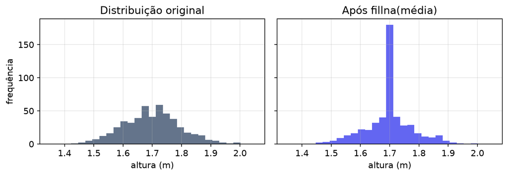

- Toda análise que dependa da **dispersão** (desvio-padrão, correlação, testes de hipótese) fica distorcida.

## `fillna` — quando usar

- **Bom para:**
  - Variáveis categóricas: `fillna("Desconhecida")` cria uma categoria à parte.
  - Colunas em que o zero é semanticamente correto (nº de compras de um cliente sem histórico).
- Sempre documente a escolha e considere criar uma coluna indicadora.

# Pandas: propagação (`ffill` e `bfill`)

## `Series.ffill` — *forward fill*

- Repete o **último valor válido** para frente, até encontrar um novo valor observado.
- Conhecido em estatística como **LOCF** (*Last Observation Carried Forward*).
- A hipótese implícita: a grandeza **persiste** entre as medições.
  - Faz sentido para: cotação de um ativo, status de um contrato, leitura de um sensor lento.
  - Não faz sentido para: dados tabulares sem ordem natural (linhas de clientes).

## `ffill` — exemplo

```python
prices = pd.Series(
    [np.nan, 31.2, np.nan, np.nan, 32.5, np.nan, 33.0],
    index=pd.date_range("2024-03-01", periods=7, freq="D"))

print(pd.DataFrame({"original": prices, "ffill": prices.ffill()}))
```

```
            original  ffill
2024-03-01       NaN    NaN
2024-03-02      31.2   31.2
2024-03-03       NaN   31.2
2024-03-04       NaN   31.2
2024-03-05      32.5   32.5
2024-03-06       NaN   32.5
2024-03-07      33.0   33.0
```

- Note que o **primeiro** valor continua ausente.

## `bfill` — *backward fill*

- Espelho do `ffill`: propaga o **próximo** valor válido para trás.

```python
print(pd.DataFrame({
    "original": prices,
    "bfill": prices.bfill(),
    "ffill+bfill": prices.ffill().bfill(),
}))
```

```
            original  bfill  ffill+bfill
2024-03-01       NaN   31.2         31.2
2024-03-02      31.2   31.2         31.2
2024-03-03       NaN   32.5         31.2
2024-03-04       NaN   32.5         31.2
2024-03-05      32.5   32.5         32.5
2024-03-06       NaN   33.0         32.5
2024-03-07      33.0   33.0         33.0
```

- `s.ffill().bfill()` é útil para propagar para frente e também preencher os valores iniciais.

## `bfill` — *backward fill*

- Cuidado: `bfill` usa informação do **futuro**.
- Em séries temporais isso é vazamento da dados.

# Pandas: interpolação

## A ideia

- A série é vista como uma **função amostrada**: os valores observados definem uma curva, e o ausente recebe o valor dessa curva no seu ponto.
- Veremos três tipos:
  - `nearest`: valor do vizinho mais próximo
  - `linear`: reta entre os vizinhos
  - `cubic`: *spline* cúbica suave

## Série de exemplo

- Temperatura horária de um dia, com dois buracos: um na subida da manhã e outro no pico da tarde.

```python
hours = np.arange(24)
truth = pd.Series((22 + 7*np.sin(2*np.pi*(hours - 9)/24)).round(1), index=hours)

gaps = [6, 7, 8, 9, 14, 15, 16, 17]
observed = truth.copy()
observed.loc[gaps] = np.nan
```

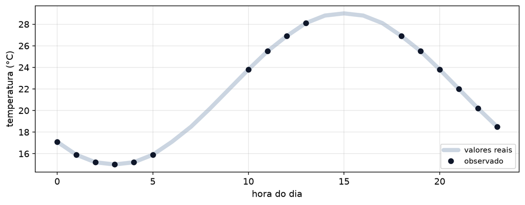

## Método `nearest`

- Cada valor ausente recebe o valor do ponto observado **mais próximo** no eixo do índice.
- O resultado é uma função **constante por partes**.
- Diferente do `ffill`, ele **olha para os dois lados**.

```python
s = pd.Series([10.0, np.nan, np.nan, 40.0, 50.0])
print(s.interpolate(method="nearest").to_numpy())
```

```
[10. 10. 40. 40. 50.]
```

## Método `linear`

- Liga o último ponto observado antes do buraco, $(x_0, y_0)$, ao primeiro depois, $(x_1, y_1)$, por um **segmento de reta**:

$$y(x) = y_0 + (y_1 - y_0)\,\frac{x - x_0}{x_1 - x_0}$$

- Propriedades:
  - A curva imputada é **contínua**, mas tem “quinas” nos pontos observados.
  - Nunca extrapola para fora do intervalo $[y_0, y_1]$, isto é, **não inventa** picos.
  - Usa apenas os **dois** vizinhos imediatos.

## `linear` — exemplo

```python
lin = observed.interpolate(method="linear")
print("imputados:", lin.loc[gaps].round(1).to_numpy())
print("verdade:  ", truth.loc[gaps].to_numpy())
def error(series):
    """Erro absoluto médio, calculado apenas nos pontos imputados."""
    return (series.loc[gaps] - truth.loc[gaps]).abs().mean()

print(f"erro médio linear: {error(lin):.2f} °C")
print(f"erro médio ffill:  {error(observed.ffill()):.2f} °C")
```

```
imputados: [17.5 19.1 20.6 22.2 27.9 27.6 27.4 27.1]
verdade:   [17.1 18.5 20.2 22.  28.8 29.  28.8 28.1]
erro médio linear: 0.79 °C
erro médio ffill:  2.06 °C
```

## `linear` — visualização

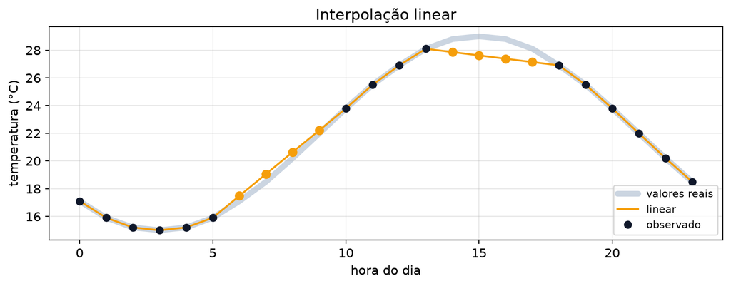

## Método `cubic`

- Ajusta uma *spline* cúbica: um polinômio de grau 3 **por intervalo** entre pontos observados.
- Os polinômios são “colados” de modo que a curva final tenha:
  - continuidade da própria função,
  - continuidade da **primeira derivada** (sem quinas),
  - continuidade da **segunda derivada** (curvatura suave).
- Consequência: a curva **acompanha a curvatura** dos dados e usa informação de **todos** os pontos, não só dos dois vizinhos.
- Requer a biblioteca `scipy` instalada.

## `cubic` — exemplo

```python
cub = observed.interpolate(method="cubic")

print(pd.DataFrame({
    "verdade": truth.loc[14:17],
    "linear": lin.loc[14:17].round(1),
    "cubic": cub.loc[14:17].round(1),
}))
print(f"erro médio cubic: {error(cub):.2f} °C")
```

```
    verdade  linear  cubic
14     28.8    27.9   28.8
15     29.0    27.6   29.0
16     28.8    27.4   28.7
17     28.1    27.1   28.0
erro médio cubic: 0.05 °C
```

- No pico (14h–17h) a linear “achata” a curva. A cúbica recupera o máximo real.

## `cubic` — visualização

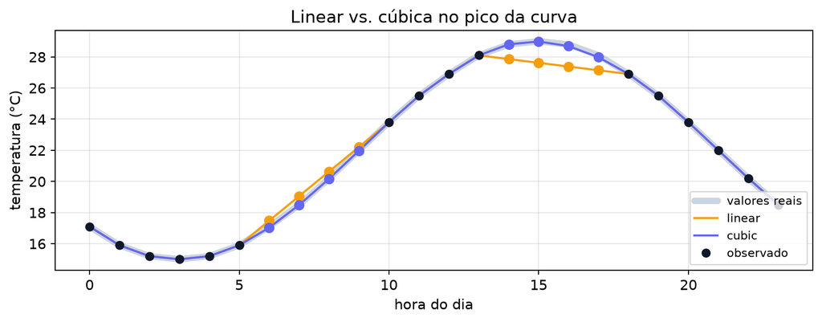

## Comparando os três métodos

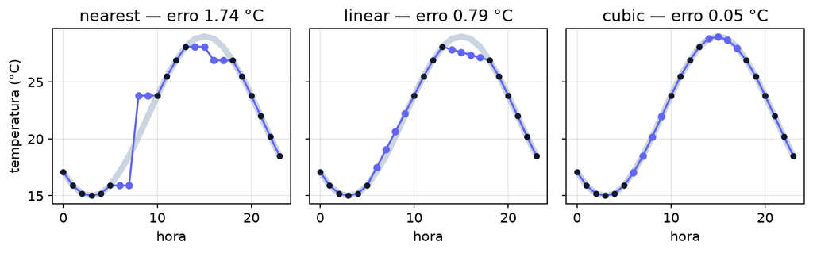

## Cuidado: a cúbica pode **inventar** valores

- A *spline* é livre para oscilar dentro do buraco. Perto de um valor atípico, ela extrapola muito além do observado.

```python
sensor = pd.Series([2.0, 2.1, 2.0, 2.2, np.nan, np.nan, np.nan,
                    np.nan, np.nan, np.nan, 9.0, 2.0, 2.1])
print("cubic: ", sensor.interpolate(method="cubic").round(1).to_numpy())
print("linear:", sensor.interpolate().round(1).to_numpy())
```

```
cubic:  [ 2.   2.1  2.   2.2  4.1  7.2 10.7 13.6 14.9 13.7  9.   2.   2.1]
linear: [2.  2.1 2.  2.2 3.2 4.1 5.1 6.1 7.1 8.  9.  2.  2.1]
```

- A cúbica chegou a **14.9**, valor maior do que qualquer leitura real do sensor.

# scikit-learn: `SimpleImputer`

## Consideração importante sobre vazamento de dados

- `s.fillna(s.mean())` **recalcula** a média em qualquer conjunto de dados a que for aplicado.
- Em aprendizado de máquina precisamos do contrário: o valor de preenchimento é um **parâmetro aprendido no treino** e reaplicado, inalterado, ao teste.
- O `scikit-learn` formaliza isso na API `fit` / `transform`:
  - `fit(X_treino)`: calcula e **guarda** a estatística.
  - `transform(X)`: aplica a estatística guardada.

## `SimpleImputer` — parâmetros

```python
SimpleImputer(missing_values=np.nan, strategy="mean",
              fill_value=None, add_indicator=False)
```

- `strategy`: `"mean"`, `"median"`, `"most_frequent"` ou `"constant"` (com `fill_value`).
- `missing_values`: o que conta como ausente (útil para sentinelas: `missing_values=-999`).
- `add_indicator`: acrescenta colunas booleanas marcando o que foi imputado.
- **Formato dos dados:** o sklearn trabalha com matrizes **2D**. Uma `Series` precisa virar `s.to_frame()`, e a saída é um `array`, não uma `Series`.

## `strategy="mean"`

```python
from sklearn.impute import SimpleImputer

heights = pd.Series([1.70, np.nan, 1.85, 1.62, np.nan, 1.78])

imp_mean = SimpleImputer(strategy="mean")
result = imp_mean.fit_transform(heights.to_frame())

print("estatística aprendida:", imp_mean.statistics_)
print(pd.Series(result.ravel(), index=heights.index).round(3).to_numpy())
```

```
estatística aprendida: [1.7375]
[1.7   1.738 1.85  1.62  1.738 1.78 ]
```

- A média fica **guardada** no objeto, em `statistics_`. Esse valor é usado para imputar os valores ausentes em conjuntos de dados futuros.

## `fit` no treino, `transform` no teste

```python
train = pd.Series([1.70, np.nan, 1.85, 1.62, 1.78])
test = pd.Series([1.90, 2.00, np.nan])        # amostra atipicamente alta

imp = SimpleImputer(strategy="mean").fit(train.to_frame())
print("média do treino:", imp.statistics_.round(3))
print("média do teste: ", round(test.mean(), 3))
print("teste imputado: ", imp.transform(test.to_frame()).ravel().round(3))
```

```
média do treino: [1.738]
média do teste:  1.95
teste imputado:  [1.9   2.    1.738]
```

- O ausente do teste recebeu **1.7375** (a média do treino), e não 1.95.

## Porque não usar a média do teste?

- Se houver apenas uma amostra de teste, a média do teste **não existe**.
- Se houver N amostras, o resultado para um item A passa a depender dos demais itens presentes.
- Desalinhamento do modelo: o modelo espera um dado normalziado pela média do treino, mas recebe um dado normalizado por outro valor.

## `strategy="median"`

- A média é sensível a *outliers*; a mediana, não.

```python
heights_error = pd.Series([1.70, np.nan, 1.85, 1.62, 19.0, 1.78])

for strategy in ["mean", "median"]:
    imp = SimpleImputer(strategy=strategy).fit(heights_error.to_frame())
    print(f"{strategy:>6}: estatística = {imp.statistics_[0]:.2f}")
```

```
  mean: estatística = 5.19
median: estatística = 1.78
```

- **mediana** é útil quando a distribuição é assimétrica ou possui *outliers*. Exemplo: renda, preço e tempo de resposta.

## `strategy="most_frequent"`

- `mean` e `median` só funcionam com números. Para **texto**, a estratégia é a moda:

```python
plans = pd.Series(
  ["basico", "premium", None, "basico", "basico", None, "premium"]
  )

imp_mode = SimpleImputer(strategy="most_frequent")
result = imp_mode.fit_transform(plans.to_frame())

print("moda aprendida:", imp_mode.statistics_)
print(pd.Series(result.ravel(), index=plans.index).to_numpy())
```

```
moda aprendida: ['basico']
['basico' 'premium' 'basico' 'basico' 'basico' 'basico' 'premium']
```

- Outra possibilidade: `SimpleImputer(strategy="constant", fill_value="desconhecido")`, que indica que o valor é desconhecido.

## `add_indicator=True`

```python
imp = SimpleImputer(strategy="mean", add_indicator=True)
print(imp.fit_transform(heights.to_frame()).round(3))
```

```
[[1.7   0.   ]
 [1.738 1.   ]
 [1.85  0.   ]
 [1.62  0.   ]
 [1.738 1.   ]
 [1.78  0.   ]]
```

- A saída ganha uma segunda coluna: `1.0` onde o valor foi imputado.
- Só são criadas colunas indicadoras para as variáveis que possuem ausências no treino.

# scikit-learn: `KNNImputer`

## A ideia

- Até aqui, cada coluna foi imputada **isoladamente**. Mas as colunas de um dataset são correlacionadas.
- `KNNImputer`: para preencher um valor da linha $i$, encontre as $k$ linhas **mais parecidas** com ela e use a **média** dos valores dessas linhas naquela coluna.
- “Parecidas” segundo as **outras** colunas, exatamente a informação que o mecanismo **MAR** exige.
- Intuição: imputar a renda de uma pessoa com base na renda média de outras pessoas com perfis semelhantes.

## Distância com valores ausentes

- Distâncias euclidianas comuns não funcionam com `NaN`. O sklearn usa a métrica `nan_euclidean`:

$$d(x, y) = \sqrt{\frac{n_{\text{total}}}{n_{\text{presentes}}} \sum_{j \,\in\, \text{presentes}} (x_j - y_j)^2}$$

- Só as coordenadas presentes **nas duas** linhas entram na soma.
- O fator $n_{\text{total}} / n_{\text{presentes}}$ reescala a distância, para que linhas comparadas em poucas coordenadas não pareçam artificialmente próximas.

## Exemplo com KNNImputer

```python
people = pd.DataFrame({
    "idade": [40, 42, 25, 26, 44, 23],
    "patrimonio": [200_000, 250_000, 15_000, 20_000, 300_000, 10_000],
    "renda": [5500, 7000, 2200, 2500, np.nan, 2500],
}, index=["Ana", "Bruno", "Carla", "Diego", "Elisa", "Fabio"])
print(people)
```

```
       idade  patrimonio   renda
Ana       40      200000  5500.0
Bruno     42      250000  7000.0
Carla     25       15000  2200.0
Diego     26       20000  2500.0
Elisa     44      300000     NaN
Fabio     23       10000  2500.0
```

- A renda de **Elisa** está ausente. Seu perfil (44 anos, patrimonio 300000) é quase idêntico ao de Ana e Bruno.

## Exemplo com KNNImputer

```python
from sklearn.impute import KNNImputer

imputed = KNNImputer(n_neighbors=2).fit_transform(people)
print(pd.DataFrame(imputed, index=people.index, columns=people.columns))
```

```
       idade  patrimonio   renda
Ana     40.0    200000.0  5500.0
Bruno   42.0    250000.0  7000.0
Carla   25.0     15000.0  2200.0
Diego   26.0     20000.0  2500.0
Elisa   44.0    300000.0  6250.0
Fabio   23.0     10000.0  2500.0
```

# scikit-learn: `IterativeImputer`

## A ideia central

- Em vez de estatística (`SimpleImputer`) ou vizinhança (`KNNImputer`), usamos **modelagem**.
- Cada coluna com ausências vira a **variável-alvo** de uma regressão que usa as demais colunas como preditoras.
- Como as preditoras também têm buracos, o processo é **iterativo**: começa com uma imputação inicial, com refinamento iterativo.
- É a implementação, no sklearn, da estratégia conhecida como **MICE** (*Multivariate Imputation by Chained Equations*).

## O algoritmo

```
X_imp = imputação_inicial(X)              # média de cada coluna (initial_strategy)

para it em 1..max_iter:                   # uma "rodada"
    para cada coluna j com ausências:     # na ordem de imputation_order
        obs   = linhas em que X[:, j] foi observado
        falta = linhas em que X[:, j] está ausente

        modelo = estimator.fit(X_imp[obs, outras_colunas], X[obs, j])
        X_imp[falta, j] = modelo.predict(X_imp[falta, outras_colunas])

    se a maior variação em relação à rodada anterior < tol: pare
```

- A cada rodada, as estimativas usadas como preditoras ficam **melhores** do que na anterior.

## Parâmetros que importam

- `estimator`: o modelo de regressão
  - O padrão é `BayesianRidge` (linear e regularizado)
  - `RandomForestRegressor` captura relações não lineares (método muito popular conhecido como *missForest*)
- `max_iter` / `tol`: número máximo de rodadas e critério de parada
- `initial_strategy`: como preencher antes da primeira rodada (`"mean"`, `"median"`, `"most_frequent"`).
- `imputation_order`: `"ascending"` (padrão) começa pela coluna com **menos** ausências, cujo modelo é mais confiável.

## API experimental

- O `IterativeImputer` ainda é considerado experimental: sua API pode mudar sem aviso de depreciação. Por isso o sklearn exige uma importação explícita:

```python
from sklearn.experimental import enable_iterative_imputer   # obrigatório, antes
from sklearn.impute import IterativeImputer
```

## Um exemplo com relação conhecida

- Três colunas de um cadastro de imóveis, geradas com uma relação conhecida: $\text{preco} \approx 3 \cdot \text{area} + 20 \cdot \text{quartos}$.

```python
rng = np.random.default_rng(7)
n = 60
area = rng.uniform(50, 200, n).round(0)
rooms = np.clip((area/40 + rng.normal(0, 0.3, n)).round(0), 1, 6)
price = (3*area + 20*rooms + rng.normal(0, 4, n)).round(0)

properties = pd.DataFrame({"area": area, "quartos": rooms, "preco": price})

with_gaps = properties.copy()
with_gaps.loc[[3, 11], "preco"] = np.nan
with_gaps.loc[[5, 20], "area"] = np.nan
print(with_gaps.loc[[3, 5, 11, 20]])
```

```
    area  quartos  preco
3   84.0      2.0    NaN
5    NaN      4.0  618.0
11  92.0      2.0    NaN
20   NaN      3.0  302.0
```

## A imputação

```python
imp_iter = IterativeImputer(max_iter=10, skip_complete=True, random_state=0)
result = pd.DataFrame(imp_iter.fit_transform(with_gaps),
                      columns=properties.columns)

mean_imputed = pd.DataFrame(SimpleImputer().fit_transform(with_gaps),
                            columns=properties.columns)

cells = [(3, "preco"), (5, "area"), (11, "preco"), (20, "area")]
print(pd.DataFrame({
    "verdade": [properties.loc[i, c] for i, c in cells],
    "IterativeImputer": [result.loc[i, c] for i, c in cells],
    "SimpleImputer(mean)": [mean_imputed.loc[i, c] for i, c in cells],
}, index=[f"{c}[{i}]" for i, c in cells]).round(1))
```

```
           verdade  IterativeImputer  SimpleImputer(mean)
preco[3]     292.0             290.9                434.7
area[5]      181.0             179.5                123.2
preco[11]    313.0             314.8                434.7
area[20]      82.0              80.9                123.2
```

## Por que o iterativo acerta

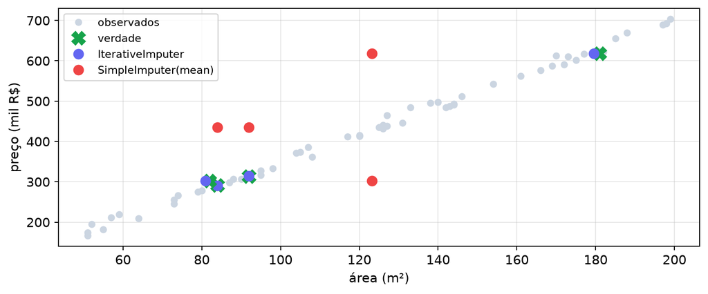

- A média joga os pontos para o centro da nuvem
- O iterativo considera **a relação** entre as variáveis.

## `imputation_sequence_`

- O atributo guarda o **histórico completo** do processo: uma tupla nomeada por (coluna imputada $\times$ rodada), na ordem em que os modelos foram ajustados.
- Cada tupla `_ImputerTriplet` tem três campos: `feat_idx` (coluna alvo), `neighbor_feat_idx` (colunas preditoras) e `estimator` (o modelo já treinado).

```python
print("rodadas executadas:", imp_iter.n_iter_)
print("modelos ajustados:", len(imp_iter.imputation_sequence_))
print(imp_iter.imputation_sequence_[0]._fields)
```

```
rodadas executadas: 3
modelos ajustados: 6
('feat_idx', 'neighbor_feat_idx', 'estimator')
```

- $6 = 2 \text{ colunas com ausência} \times 3 \text{ rodadas}$.

## Lendo a sequência

```python
columns = properties.columns

for i, step in enumerate(imp_iter.imputation_sequence_):
    target = columns[step.feat_idx]
    predictors = list(columns[list(step.neighbor_feat_idx)])
    coefs = step.estimator.coef_.round(2)
    print(f"rodada {i//2 + 1}: {target:>5} <- {str(predictors):<22} coef = {coefs}")
```

```
rodada 1:  area <- ['quartos', 'preco']   coef = [0.05 0.28]
rodada 1: preco <- ['area', 'quartos']    coef = [ 3.03 19.24]
rodada 2:  area <- ['quartos', 'preco']   coef = [-6.77  0.33]
rodada 2: preco <- ['area', 'quartos']    coef = [ 2.98 20.9 ]
rodada 3:  area <- ['quartos', 'preco']   coef = [-6.77  0.33]
rodada 3: preco <- ['area', 'quartos']    coef = [ 2.98 20.91]
```

- O processo parou na 3ª rodada porque os valores imputados praticamente não mudaram (`tol`).

# Considerações adicionais sobre imputação

## Modelos que convivem com `NaN`

- Em aprendizado de máquina tabular, uma decisão muito comum é **não imputar**: escolher um modelo que trata a ausência internamente.
- A ausência vira **parte do modelo**, e não um valor inventado.
- Fazem isso nativamente: `HistGradientBoostingRegressor`/`Classifier` do sklearn, **LightGBM**, **XGBoost**, **CatBoost** e, nas versões recentes, também `DecisionTree` e `RandomForest`.
- Modelos lineares, SVMs, redes neurais e métodos de projeção (PCA) **continuam** exigindo imputação.

## Exemplo de regressão com `NaN`

```python
from sklearn.ensemble import HistGradientBoostingRegressor

X = with_gaps[["area", "quartos"]]        # a coluna 'area' tem ausentes
y = properties["preco"]

model = HistGradientBoostingRegressor(random_state=0).fit(X, y)
new_sample = pd.DataFrame({"area": [np.nan], "quartos": [3.0]})
print("HistGradientBoosting previu:", model.predict(new_sample).round(1))
```

```
HistGradientBoosting previu: [403.7]
```

## Um imputador por tipo de coluna

- Datasets reais misturam colunas numéricas e categóricas, e cada tipo precisa de uma estratégia diferente.
- É possível criar um **imputador diferente** para cada coluna com `ColumnTransformer`:

## Um imputador por tipo de coluna

Exemplo

```python
from sklearn.compose import ColumnTransformer

records = pd.DataFrame({"idade": [30.0, np.nan, 45.0],
                        "cidade": ["SP", None, "RJ"]})

# num e cat são nomes das transformações, usados para identificar as colunas de saída
preprocessing = ColumnTransformer([
    ("num", SimpleImputer(strategy="median", add_indicator=True), ["idade"]),
    ("cat", SimpleImputer(strategy="most_frequent"), ["cidade"]),
])

print(preprocessing.fit_transform(records))
print(preprocessing.get_feature_names_out())
```

```
[[30.0 0.0 'SP']
 [37.5 1.0 'RJ']
 [45.0 0.0 'RJ']]
['num__idade' 'num__missingindicator_idade' 'cat__cidade']
```